# Homework 01

## Question 1 (Least squares and matrix calculations)

Set the random seed to 43201. Generate $n=100$ observations with $p=5$ predictors according to

$$x_{ij}\overset{\mathrm{iid}}{\sim}N(0,1),
\qquad
\varepsilon_i\overset{\mathrm{iid}}{\sim}N(0,0.7^2),$$

with all predictors and errors generated independently. Let

$$\mathbf X
=
\begin{bmatrix}
\mathbf 1 & \mathbf x_1 & \cdots & \mathbf x_5
\end{bmatrix},
\qquad
\boldsymbol\beta
=
(3,1.4,-0.9,0.7,0,1.1)^{\mathsf T},$$

and generate

$$\mathbf y=\mathbf X\boldsymbol\beta+\boldsymbol\varepsilon.$$

1. Generate the data and report the dimensions and rank of $\mathbf X$. Calculate the least-squares estimate $\widehat{\boldsymbol\beta}$ using a numerically stable least-squares routine, without explicitly calculating $(\mathbf X^{\mathsf T}\mathbf X)^{-1}$. Compare the estimates with the coefficients used to generate the data.
2. Calculate the fitted values, the residual vector $\mathbf r=\mathbf y-\mathbf X\widehat{\boldsymbol\beta}$, and the training root mean squared error

$$\operatorname{RMSE}
=
\left(
\frac{1}{n}\sum_{i=1}^{n}r_i^2
\right)^{1/2}.$$

3. Report $\lVert\mathbf X^{\mathsf T}\mathbf r\rVert_\infty$. Explain why this value should be close to zero and what it tells us about the residual vector.

### Solution

#### Part a

The intercept and five predictors give $\mathbf X$ 100 rows and 6 columns. I use `numpy.linalg.lstsq`, which computes the least-squares solution without explicitly forming or inverting $\mathbf X^{\mathsf T}\mathbf X$.

**Show the solution code**

```python
import numpy as np
import pandas as pd
import matplotlib.pyplot as plt
from IPython.display import display

rng = np.random.default_rng(43201)

n = 100
p = 5
x = rng.normal(size=(n, p))
X = np.column_stack([np.ones(n), x])
coefficient_names = ["Intercept", "x1", "x2", "x3", "x4", "x5"]
beta = np.array([3.0, 1.4, -0.9, 0.7, 0.0, 1.1])
epsilon = rng.normal(loc=0.0, scale=0.7, size=n)
y = X @ beta + epsilon

beta_hat, _, rank_X, singular_values = np.linalg.lstsq(X, y, rcond=None)

coefficient_comparison = pd.DataFrame(
    {
        "coefficient": coefficient_names,
        "generating value": beta,
        "estimate": beta_hat,
        "estimation error": beta_hat - beta,
    }
)

print(f"Dimensions of X: {X.shape}")
print(f"Rank of X: {rank_X}")
display(coefficient_comparison.round(4))
```

```
Dimensions of X: (100, 6)
Rank of X: 6
```

|  | coefficient | generating value | estimate | estimation error |
| --- | --- | --- | --- | --- |
| 0 | Intercept | 3.0 | 2.9731 | -0.0269 |
| 1 | x1 | 1.4 | 1.3240 | -0.0760 |
| 2 | x2 | -0.9 | -0.8415 | 0.0585 |
| 3 | x3 | 0.7 | 0.7204 | 0.0204 |
| 4 | x4 | 0.0 | -0.0831 | -0.0831 |
| 5 | x5 | 1.1 | 1.1651 | 0.0651 |

The estimates are approximately

$$\widehat{\boldsymbol\beta}
=
(2.973,\ 1.324,\ -0.841,\ 0.720,\ -0.083,\ 1.165)^{\mathsf T}.$$

They are reasonably close to the generating coefficients. Exact agreement is not expected because the response includes one random realization of the noise.

#### Part b

**Show the solution code**

```python
fitted_values = X @ beta_hat
residuals = y - fitted_values
training_rmse = np.sqrt(np.mean(residuals**2))

fit_preview = pd.DataFrame(
    {
        "y": y,
        "fitted value": fitted_values,
        "residual": residuals,
    }
)

print("First six fitted values and residuals:")
display(fit_preview.head(6).round(4))
print(f"Training RMSE: {training_rmse:.6f}")
```

```
First six fitted values and residuals:
```

|  | y | fitted value | residual |
| --- | --- | --- | --- |
| 0 | 1.4994 | 0.4284 | 1.0710 |
| 1 | 2.9202 | 2.6798 | 0.2404 |
| 2 | 6.6809 | 6.6011 | 0.0798 |
| 3 | -2.0687 | -1.9718 | -0.0970 |
| 4 | 2.6943 | 2.2709 | 0.4234 |
| 5 | 0.2889 | 0.2465 | 0.0423 |

```
Training RMSE: 0.646340
```

The training RMSE is approximately $0.6463$. The code calculates all 100 fitted values and residuals; the table displays the first six to keep the report readable.

#### Part c

**Show the solution code**

```python
normal_equation_vector = X.T @ residuals
normal_equation_error = np.max(np.abs(normal_equation_vector))

print("X^T r:", normal_equation_vector)
print(f"Infinity norm of X^T r: {normal_equation_error:.3e}")
```

```
X^T r: [ 4.39648318e-14 -3.07309733e-13 -8.96061003e-13  3.72812892e-13
 -1.36052281e-12  1.90847338e-13]
Infinity norm of X^T r: 1.361e-12
```

The value is on the order of $10^{-12}$, which is effectively zero at floating-point precision. The gradient of the residual sum of squares is

$$-2\mathbf X^{\mathsf T}(\mathbf y-\mathbf X\boldsymbol\beta).$$

Therefore, the least-squares first-order condition is $\mathbf X^{\mathsf T}\mathbf r=\mathbf 0$. Geometrically, the residual vector is orthogonal to every column of $\mathbf X$. Its orthogonality to the intercept column also means that the residuals sum to approximately zero.

## Question 2 (Gaussian likelihood for linear regression)

Continue with the data from Question 1. Suppose

$$\mathbf Y\mid\mathbf X
\sim
N_n\left(\mathbf X\boldsymbol\beta,\sigma^2\mathbf I_n\right).$$

The log-likelihood, including the constant term, is

$$\ell(\boldsymbol\beta,\sigma^2)
=
-\frac{n}{2}\log(2\pi\sigma^2)
-\frac{1}{2\sigma^2}
(\mathbf y-\mathbf X\boldsymbol\beta)^{\mathsf T}
(\mathbf y-\mathbf X\boldsymbol\beta).$$

1. For fixed $\sigma^2$, explain why maximizing $\ell(\boldsymbol\beta,\sigma^2)$ over $\boldsymbol\beta$ is equivalent to minimizing the residual sum of squares. What does this imply about the maximum-likelihood estimate of $\boldsymbol\beta$?
2. For fixed $\boldsymbol\beta$, differentiate the log-likelihood with respect to $\sigma^2$ and derive its maximum-likelihood estimate. Calculate this estimate at $\widehat{\boldsymbol\beta}$ and compare it with the unbiased estimate of $\sigma^2$. Explain why the two denominators differ.
3. Let

$$\mathbf e_{x_2}=(0,0,1,0,0,0)^{\mathsf T}.$$

Using the variance estimate from part b, plot

$$\ell\left(
\widehat{\boldsymbol\beta}+t\mathbf e_{x_2},
\widehat{\sigma}_{\mathrm{MLE}}^2
\right)$$

over a grid of $t$ values from $-1.25$ to $1.25$. State where the maximum occurs and explain why this agrees with the least-squares result.

### Solution

#### Part a

For fixed $\sigma^2$, the term $-n\log(2\pi\sigma^2)/2$ is constant with respect to $\boldsymbol\beta$, and the residual sum of squares is multiplied by the negative constant $-1/(2\sigma^2)$. Hence,

$$\underset{\boldsymbol\beta}{\operatorname{argmax}}\,
\ell(\boldsymbol\beta,\sigma^2)
=
\underset{\boldsymbol\beta}{\operatorname{argmin}}\,
(\mathbf y-\mathbf X\boldsymbol\beta)^{\mathsf T}
(\mathbf y-\mathbf X\boldsymbol\beta).$$

Thus the maximum-likelihood estimate of $\boldsymbol\beta$ is exactly the least-squares estimate $\widehat{\boldsymbol\beta}$ from Question 1.

#### Part b

Let $v=\sigma^2$ and write $\operatorname{RSS}(\boldsymbol\beta)=\lVert\mathbf y-\mathbf X\boldsymbol\beta\rVert_2^2$. For fixed $\boldsymbol\beta$,

$$\ell(\boldsymbol\beta,v)
=-\frac{n}{2}\log(2\pi v)-\frac{\operatorname{RSS}(\boldsymbol\beta)}{2v},$$

so

$$\frac{\partial\ell}{\partial v}
=-\frac{n}{2v}+\frac{\operatorname{RSS}(\boldsymbol\beta)}{2v^2}.$$

Equating this derivative to zero gives

$$\widehat\sigma^2_{\mathrm{MLE}}=\frac{\operatorname{RSS}}{n}.$$

At this stationary point the second derivative is $-n/(2\widehat{\sigma}_{\mathrm{MLE}}^4)<0$, so it is a maximum.

**Show the solution code**

```python
rss = residuals @ residuals
sigma2_mle = rss / n
sigma2_unbiased = rss / (n - X.shape[1])

variance_comparison = pd.DataFrame(
    {
        "estimator": ["MLE", "Unbiased"],
        "denominator": [n, n - X.shape[1]],
        "estimate": [sigma2_mle, sigma2_unbiased],
    }
)
display(variance_comparison.round(6))
```

|  | estimator | denominator | estimate |
| --- | --- | --- | --- |
| 0 | MLE | 100 | 0.417755 |
| 1 | Unbiased | 94 | 0.444420 |

The MLE is approximately $0.4178$, whereas the unbiased estimate is approximately $0.4444$. Maximum likelihood divides by $n$ because that value directly maximizes the likelihood. The unbiased estimator divides by $n-6$ because six regression coefficients were estimated and

$$\mathbb E(\operatorname{RSS})=(n-6)\sigma^2.$$

#### Part c

**Show the solution code**

```
Maximizing grid value of t: 0.00
```

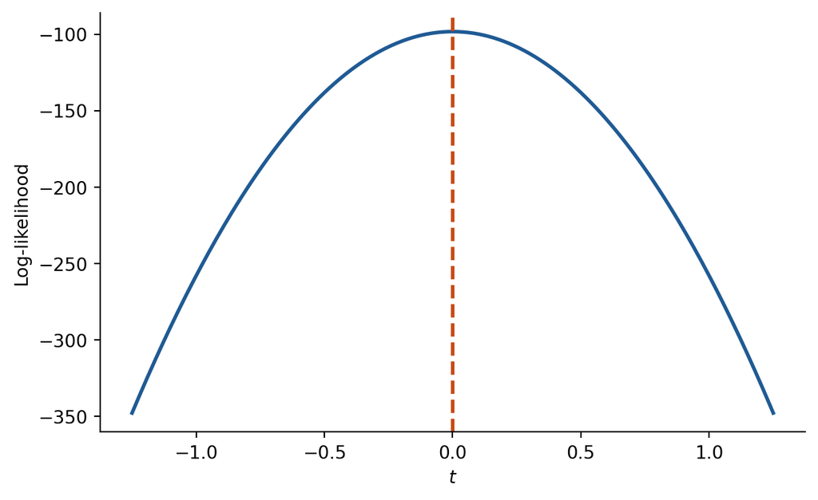

Likelihood profile obtained by changing only the coefficient of x2.

```python
def log_likelihood(beta_value, sigma2, design, response):
    likelihood_residual = response - design @ beta_value
    return (
        -design.shape[0] / 2 * np.log(2 * np.pi * sigma2)
        - likelihood_residual @ likelihood_residual / (2 * sigma2)
    )

e_x2 = np.array([0.0, 0.0, 1.0, 0.0, 0.0, 0.0])
t_grid = np.linspace(-1.25, 1.25, 251)
profile_log_likelihood = np.array(
    [
        log_likelihood(beta_hat + t * e_x2, sigma2_mle, X, y)
        for t in t_grid
    ]
)
maximizing_t = t_grid[np.argmax(profile_log_likelihood)]

print(f"Maximizing grid value of t: {maximizing_t:.2f}")

fig, ax = plt.subplots(figsize=(7, 4.2))
ax.plot(t_grid, profile_log_likelihood, color="#1F5A94", linewidth=2)
ax.axvline(0, color="#C84A16", linestyle="--", linewidth=2)
ax.set(xlabel=r"$t$", ylabel="Log-likelihood")
ax.spines[["top", "right"]].set_visible(False)
plt.show()
```

The maximum occurs at $t=0$. This value leaves the coefficient vector at $\widehat{\boldsymbol\beta}$. Any nonzero $t$ moves away from the least-squares minimizer, increases the residual sum of squares, and therefore decreases the log-likelihood for the fixed variance.

## Question 3 (Starting values in nonconvex optimization)

Consider the function

$$f(x)=\exp(1.5x)-3(x+6)^2-0.05x^3,$$

with derivative

$$f'(x)=1.5\exp(1.5x)-6(x+6)-0.15x^2.$$

1. Plot $f(x)$ over the interval $[-40,7]$. Based on the plot, describe the important features of the objective function that may affect numerical optimization.
2. Use BFGS to minimize $f(x)$ twice, starting at $x^{(0)}=-15$ and $x^{(0)}=0$. Supply $f'(x)$ to the optimizer. For each run, report the final value of $x$, the final objective value, $|f'(x)|$, and whether the optimizer reported convergence.
3. Explain why the two runs can converge to different answers. Which run gives the lower objective value? What additional evidence would be needed before claiming that this point is the global minimum?

### Solution

#### Part a

**Show the solution code**

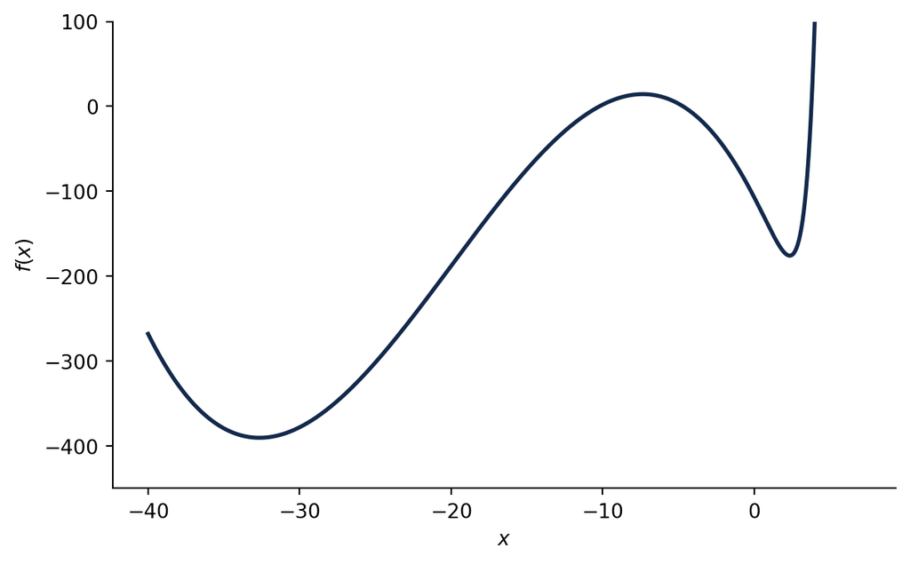

The nonconvex objective over the specified interval. The vertical range is restricted so both minima remain visible.

```python
def objective(x_value):
    return (
        np.exp(1.5 * x_value)
        - 3 * (x_value + 6) ** 2
        - 0.05 * x_value**3
    )

def gradient(x_value):
    return (
        1.5 * np.exp(1.5 * x_value)
        - 6 * (x_value + 6)
        - 0.15 * x_value**2
    )

x_grid = np.linspace(-40, 7, 1200)

fig, ax = plt.subplots(figsize=(7, 4.2))
ax.plot(x_grid, objective(x_grid), color="#13294B", linewidth=2)
ax.set(xlabel=r"$x$", ylabel=r"$f(x)$", ylim=(-450, 100))
ax.spines[["top", "right"]].set_visible(False)
plt.show()
```

The plot has two separated low regions, with a local maximum between them, and the function rises sharply near the right endpoint because of the exponential term. Thus the objective is nonconvex and contains multiple basins of attraction. A local gradient-based method can converge to different stationary points depending on its initial value. The restricted vertical scale affects only the display, not the objective used below.

#### Part b

**Show the solution code**

```python
from scipy.optimize import minimize

starts = [-15.0, 0.0]
optimization_results = []

for start in starts:
    result = minimize(
        fun=lambda value: objective(value[0]),
        x0=np.array([start]),
        jac=lambda value: np.array([gradient(value[0])]),
        method="BFGS",
    )
    optimization_results.append(result)

optimization_summary = pd.DataFrame(
    [
        {
            "starting value": start,
            "final x": result.x[0],
            "final objective": result.fun,
            "absolute gradient": abs(gradient(result.x[0])),
            "converged": result.success,
            "optimizer message": result.message,
        }
        for start, result in zip(starts, optimization_results)
    ]
)
display(optimization_summary)
```

|  | starting value | final x | final objective | absolute gradient | converged | optimizer message |
| --- | --- | --- | --- | --- | --- | --- |
| 0 | -15.0 | -32.649111 | -390.38577 | 2.842171e-14 | True | Optimization terminated successfully. |
| 1 | 0.0 | 2.349967 | -175.86262 | 8.126811e-06 | True | Optimization terminated successfully. |

Starting from $-15$, BFGS converges to approximately $x=-32.64911$, where $f(x)=-390.38577$. Starting from $0$, it converges to approximately $x=2.34997$, where $f(x)=-175.86262$. Both runs report convergence and have gradients numerically close to zero.

#### Part c

BFGS is a local optimization method: it uses local function and gradient information and does not generally cross the local maximum separating the two basins. Consequently, the two starting values lead to different local minima. The run beginning at $-15$ produces the lower objective value.

Convergence and a small gradient establish only that a run has reached a stationary point. Before claiming global optimality, we would need evidence that no lower region was missed. For this one-dimensional problem, one could study the limiting behavior at both ends, find all roots of $f'(x)$, classify every stationary point using sign changes or $f''(x)$, and compare all their objective values. A dense grid and many starting values provide useful numerical evidence but not, by themselves, a proof.

## Question 4 (Nearly collinear predictors)

Continue with $\mathbf X$ and $\mathbf y$ from Question 1. Set the random seed to 43202 and generate

$$u_i\overset{\mathrm{iid}}{\sim}N(0,1),
\qquad i=1,\ldots,n.$$

Define

$$\mathbf x_6=\mathbf x_1+10^{-4}\mathbf u,
\qquad
\mathbf X_+
=
\begin{bmatrix}
\mathbf X & \mathbf x_6
\end{bmatrix},$$

and let

$$\mathbf y^\star=\mathbf y+10^{-3}\mathbf u.$$

Use a numerically stable least-squares routine throughout.

1. Fit $\mathbf y$ using $\mathbf X$ and $\mathbf X_+$. For each design matrix, report the condition number and training RMSE. For the augmented fit, also report the coefficients of $\mathbf x_1$ and $\mathbf x_6$.
2. Fit $\mathbf y^\star$ using $\mathbf X_+$. Report the changes in the coefficients of $\mathbf x_1$ and $\mathbf x_6$. Compare the two fitted-value vectors using their root mean squared difference and maximum absolute difference.
3. Use the identity

$$\mathbf y^\star-\mathbf y
=
10(\mathbf x_6-\mathbf x_1)$$

to explain why the fitted values change very little while the two coefficients change substantially. What does this example suggest about interpreting separate effects for nearly collinear predictors?

### Solution

#### Part a

**Show the solution code**

```python
rng_q4 = np.random.default_rng(43202)
u = rng_q4.normal(size=n)

x6 = x[:, 0] + 1e-4 * u
X_plus = np.column_stack([X, x6])
y_star = y + 1e-3 * u

beta_original = np.linalg.lstsq(X, y, rcond=None)[0]
beta_augmented = np.linalg.lstsq(X_plus, y, rcond=None)[0]

fitted_original = X @ beta_original
fitted_augmented = X_plus @ beta_augmented

fit_comparison = pd.DataFrame(
    {
        "design": ["X", "X_plus"],
        "condition number": [np.linalg.cond(X), np.linalg.cond(X_plus)],
        "training RMSE": [
            np.sqrt(np.mean((y - fitted_original) ** 2)),
            np.sqrt(np.mean((y - fitted_augmented) ** 2)),
        ],
    }
)

display(fit_comparison)
print(f"Augmented-fit coefficient of x1: {beta_augmented[1]:.6f}")
print(f"Augmented-fit coefficient of x6: {beta_augmented[6]:.6f}")
print(f"Their sum: {beta_augmented[1] + beta_augmented[6]:.6f}")
```

|  | design | condition number | training RMSE |
| --- | --- | --- | --- |
| 0 | X | 1.452504 | 0.646340 |
| 1 | X_plus | 20339.835807 | 0.633956 |

```
Augmented-fit coefficient of x1: -1329.743016
Augmented-fit coefficient of x6: 1331.060139
Their sum: 1.317123
```

#### Part b

**Show the solution code**

```python
beta_perturbed = np.linalg.lstsq(X_plus, y_star, rcond=None)[0]
fitted_perturbed = X_plus @ beta_perturbed

coefficient_comparison_q4 = pd.DataFrame(
    {
        "coefficient": ["x1", "x6"],
        "fit to y": beta_augmented[[1, 6]],
        "fit to y_star": beta_perturbed[[1, 6]],
        "change": beta_perturbed[[1, 6]] - beta_augmented[[1, 6]],
    }
)

fitted_difference = fitted_perturbed - fitted_augmented
fitted_difference_rmse = np.sqrt(np.mean(fitted_difference**2))
fitted_difference_max = np.max(np.abs(fitted_difference))

display(coefficient_comparison_q4)
print(f"Fitted-value difference RMSE: {fitted_difference_rmse:.8f}")
print(f"Maximum absolute fitted-value difference: {fitted_difference_max:.8f}")
```

|  | coefficient | fit to y | fit to y_star | change |
| --- | --- | --- | --- | --- |
| 0 | x1 | -1329.743016 | -1339.743016 | -10.0 |
| 1 | x6 | 1331.060139 | 1341.060139 | 10.0 |

```
Fitted-value difference RMSE: 0.00097498
Maximum absolute fitted-value difference: 0.00235117
```

The $x_1$ coefficient changes by approximately $-10$ and the $x_6$ coefficient changes by approximately $+10$. In contrast, the two fitted-value vectors differ by an RMSE of only about $0.000975$ and a maximum absolute difference of about $0.00235$.

#### Part c

Because

$$\mathbf y^\star-\mathbf y
=10^{-3}\mathbf u
=10^{-3}\frac{\mathbf x_6-\mathbf x_1}{10^{-4}}
=10(\mathbf x_6-\mathbf x_1),$$

the augmented model can reproduce the entire response perturbation by changing the coefficient of $x_1$ by $-10$ and that of $x_6$ by $+10$. The resulting change in the fitted values is nevertheless only $10^{-3}\mathbf u$, so its entries are typically on the order of one-thousandth.

Thus, nearly collinear predictors create a coefficient direction in which very large, opposing coefficient changes produce very small prediction changes. The data identify the predictors’ combined contribution much more reliably than their separate effects, so individual coefficients should not be given stable separate-effect interpretations in this setting.

## Question 5 (Data preparation and summary statistics)

The file `data/data-manipulation.csv` is a small constructed data table containing an observation identifier, a group label, two numeric predictors, and a response. Some response values are missing. For analyses involving the response, use only observations with a recorded response. Do not replace a missing response with zero or a group mean.

1. Read the data and report its dimensions, column types, number of duplicated identifiers, and number of missing values in each column. Create an analysis table containing only observations with a recorded response, and define

$$\texttt{feature\_sum}=\texttt{x1}+\texttt{x2}.$$

2. For each group, report the number of observations, the mean response, and the mean of `feature_sum`. State clearly which observations these summaries describe.
3. Sort the analysis table by response from largest to smallest and report the first three rows, including `observation_id`, `group`, `response`, and `feature_sum`. Add code checks verifying that the number of retained rows equals the number of nonmissing responses in the original data, that the analysis table has no missing response values, and that its identifiers are unique.

### Solution

#### Part a

**Show the solution code**

```python
from pathlib import Path

data_file = Path("data") / "data-manipulation.csv"
small_data = pd.read_csv(data_file)

print(f"Dimensions: {small_data.shape}")
print("\nColumn types:")
display(small_data.dtypes.rename("dtype").to_frame())
print(
    "Duplicated identifiers:",
    small_data["observation_id"].duplicated().sum(),
)
print("\nMissing values by column:")
display(small_data.isna().sum().rename("missing").to_frame())

analysis_data = small_data.dropna(subset=["response"]).copy()
analysis_data["feature_sum"] = analysis_data["x1"] + analysis_data["x2"]

print(f"Rows in response analysis table: {len(analysis_data)}")
```

```
Dimensions: (24, 5)

Column types:
```

|  | dtype |
| --- | --- |
| observation_id | object |
| group | object |
| x1 | float64 |
| x2 | float64 |
| response | float64 |

```
Duplicated identifiers: 0

Missing values by column:
```

|  | missing |
| --- | --- |
| observation_id | 0 |
| group | 0 |
| x1 | 0 |
| x2 | 0 |
| response | 3 |

```
Rows in response analysis table: 21
```

The original table has 24 rows and 5 columns. `observation_id` and `group` are text columns, while `x1`, `x2`, and `response` are numeric. There are no duplicated identifiers. Only `response` has missing values: three responses are missing, so the response analysis table contains 21 rows. No imputed values are introduced.

#### Part b

**Show the solution code**

```python
group_summary = (
    analysis_data.groupby("group", as_index=False)
    .agg(
        observations=("response", "size"),
        mean_response=("response", "mean"),
        mean_feature_sum=("feature_sum", "mean"),
    )
)
display(group_summary.round(4))
```

|  | group | observations | mean_response | mean_feature_sum |
| --- | --- | --- | --- | --- |
| 0 | A | 7 | 5.6000 | 3.6000 |
| 1 | B | 7 | 7.6029 | 4.9286 |
| 2 | C | 7 | 7.9971 | 6.5857 |

Each group contributes seven observations with a recorded response. The summaries describe only these 21 complete-response observations, not all 24 rows of the original table.

#### Part c

**Show the solution code**

```python
largest_three = (
    analysis_data.sort_values("response", ascending=False)
    .loc[:, ["observation_id", "group", "response", "feature_sum"]]
    .head(3)
)
display(largest_three)

number_recorded = small_data["response"].notna().sum()

assert len(analysis_data) == number_recorded
assert not analysis_data["response"].isna().any()
assert analysis_data["observation_id"].is_unique

print("All three integrity checks passed.")
print(f"Retained rows = nonmissing original responses = {number_recorded}.")
```

|  | observation_id | group | response | feature_sum |
| --- | --- | --- | --- | --- |
| 21 | obs-22 | C | 9.24 | 6.6 |
| 15 | obs-16 | B | 9.00 | 5.2 |
| 13 | obs-14 | B | 8.66 | 5.0 |

```
All three integrity checks passed.
Retained rows = nonmissing original responses = 21.
```

The three largest responses belong to `obs-22`, `obs-16`, and `obs-14`. The assertions verify the requested row-count, nonmissing-response, and unique-identifier conditions during rendering.

## Question 6 (Can 39 million Fitbit records represent US adults?)

[Patten et al. (2026)](https://doi.org/10.1038/s41591-026-04352-3) describe Fitbit data from 59,018 participants in the All of Us Research Program. The dataset spans 14 years and contains more than 39 million daily step records. Participants contributed data through one of two routes:

- Bring Your Own Device (BYOD): participants shared data from a Fitbit they already owned.
- Wearables Enhancing All of Us Research (WEAR): invited participants received a Fitbit at no cost.

In the general activity cohort, the BYOD and WEAR groups contained 32,035 and 22,474 participants, respectively. The BYOD value is listed first in each comparison below:

- 77.3% versus 55.1% reported being White;
- 6.1% versus 15.2% reported annual household income between $\$10{,}000$ and $\$25{,}000$; and
- median daily steps were 6,867 versus 5,797.

Suppose the target is the mean of the participant-specific average daily step counts among US adults during the study period, with each adult given equal weight. A researcher writes:

> “This dataset contains more than 39 million daily Fitbit records. Therefore, the average of all recorded step counts should provide an accurate estimate of mean daily activity among US adults.”
1. Are the 39 million daily records independent observations? What characteristics or behaviors could cause some participants to contribute more recorded days than others? Explain how averaging all recorded days would then weight participants unequally.
2. BYOD participants reported a median of 6,867 daily steps, compared with 5,797 among WEAR participants. Does this comparison show that already owning a Fitbit causes people to walk more? Explain your answer and give at least one plausible alternative explanation based on how participants entered the two groups.
3. A very large dataset can still produce a biased estimate of a population quantity when the people and observations entering the dataset are selected. Using this study, explain how selection of both participants and recorded days could make the observed data differ from the US adult population. Why might the naive average of all recorded daily step counts fail to estimate the stated target? You do not need to determine the direction of the bias.

### Source

Patten, T., Preble, E. A., Master, H., et al. (2026). [The All of Us Research Program’s wearables dataset](https://doi.org/10.1038/s41591-026-04352-3). *Nature Medicine*, 32, 2302-2310.

### Solution

#### Part a

The 39 million records are not 39 million independent observations. They are repeated daily measurements from about 59,000 participants, and records from the same person are likely correlated because health, occupation, habits, location, and other determinants of activity persist over time. An uncertainty calculation that treats every day as an independent sampled adult would therefore exhibit pseudoreplication and overstate the effective sample size.

Participants can contribute different numbers of days because of differences in enrollment time, consistent device wear, account synchronization, technical access, device failure, missing or invalid days, illness, travel, privacy concerns, or withdrawal. Some of these factors may also be associated with activity. The naive daily-record average can be written as

$$\frac{\sum_i\sum_{j=1}^{m_i}Y_{ij}}{\sum_i m_i}
=
\frac{\sum_i m_i\overline Y_i}{\sum_i m_i},$$

where $m_i$ is participant $i$’s number of recorded days. Thus participant $i$ receives weight proportional to $m_i$, rather than the equal weight required by the stated target.

#### Part b

No. The BYOD and WEAR routes do not randomly assign prior Fitbit ownership. BYOD participants selected themselves by already owning a compatible device and agreeing to share its data, whereas WEAR participants were invited and given a device. These groups may differ before measurement in income, technology access, health awareness, motivation, baseline activity, occupation, or health status. The reported differences in race and income provide evidence that their compositions differ. Consequently, the 1,070-step difference in medians may reflect confounding or selection into the two routes rather than a causal effect of owning a Fitbit.

For example, people who are already more active or more interested in tracking exercise may be more likely to purchase a Fitbit. In that case, higher BYOD activity would partly precede Fitbit ownership rather than be caused by it.

#### Part c

There are at least two levels of selection:

1. **Participant selection.** A person must enroll voluntarily in All of Us and then enter through BYOD or be invited to WEAR, accept the device, consent to sharing, and connect an account. These requirements can make observed participants differ from US adults in demographics, health, income, technology access, and interest in health research. Providing free devices reduces one ownership barrier but does not eliminate the other selection stages.
2. **Recorded-day selection.** An enrolled participant must wear and synchronize the device and produce a valid record on a given day. Missingness can depend on the participant and on the day’s activity—for example, the device might be removed during illness, travel, unusual work, or particular exercise.

A large number of records reduces random variation around a statistic of the observed participant-days, but it does not eliminate systematic selection bias. The naive record-level mean fails to match the target because it both overweights participants with more recorded days and may average over a participant sample that is not representative of US adults. The direction of the resulting bias cannot be determined from the record count alone.

An analysis aimed at the stated target should first compute an average within each participant so that observed participants receive equal weight, account for repeated-measure dependence, and then consider population weighting or calibration for participant selection. Even those adjustments require assumptions, especially when selection depends on unmeasured characteristics.